# RStudio Server on Talapas

UO BGMP 2018 Cohort

Kohl Kinning

19 November 2018

# Set up SSH keys

## Create the RSA Key Pair

The first step is to create the key pair on the client machine, your computer:

```bash
ssh-keygen -t rsa
```

## Store the keys and passphrase

Once you have entered the Gen Key command, you will get a few more questions:

```
Enter file in which to save the key (~/.ssh/id_rsa):
```

You can press enter here, saving the file to the user home.

```
Enter passphrase (empty for no passphrase):
```

Hit enter twice for no passphrase. This then generates two files in your local ‘~/.ssh’ directory, which looks like this:

```
.
├── id_rsa
├── id_rsa.pub
└── known_hosts
```

Id_rsa is your private key, that can stay in your directory, the id_rsa.pub contains your public key for paired authentication.

Talapas may have some rsa_key authentication setup already. It may look like:

```
.
├── authorized_keys
├── config
├── id_ecdsa
├── id_ecdsa.pub
├── id_rsa
├── id_rsa.pub
├── known_hosts
└── profile
```

To add your public key to ~/.ssh/authorized_keys, execute the from your local machine following at your own discretion:

```bash
cat ~/.ssh/id_rsa.pub | ssh kkinning@talapas-ln1.uoregon.edu "cat >> ~/.ssh/authorized_keys"
```

This step will prompt you for a password because the paired authentication has not been setup yet.

If you see the following message it is because this was the first time you have connected to that server and it must be added to the known hosts on the computer you are connecting to: type yes and hit enter.

```
The authenticity of host '111.111.11.111 (111.111.11.111)' can't be established.
ECDSA key fingerprint is fd:fd:d4:f9:77:fe:73:84:e1:55:00:ad:d6:6d:22:fe.
Are you sure you want to continue connecting (yes/no)? yes
```

If you setup ssh-keygen without a passphrase, you should now be able to ssh into any of the computational servers without having to type in a password.

# RStudio server

It’s time to spin up an RStudio server session on Talapas. In some infrastructures, this is installed on the HPC and running all of the time. It’s usually not the case if the HOPC has a workload manager like SLURM or Sun Grid Engine. At least in the free version of RStudio server there is no interface between RStudio and the workload manager, so you’d have free reign of whatever resources were available to the client running the server.

Talapas does support Singularity. Singularity is an operating system visualization containerization tool. It’s a lot like Docker. When you load up a Singularity image all of the parts an application needs, such as libraries and other dependencies, are packaged with it. Lucky for us, there is an RStudio server Singularity image on Github.

The github repo is [here](https://github.com/nickjer/singularity-rstudio).

Request an interactive node on Talapas, module load singularity.

```bash
srun --mem=16000 --pty bash
ml singularity
```

Retrieve the singularity image.

```bash
singularity pull --name singularity-rstudio.simg shub://nickjer/singularity-rstudio
```

Launch the singularity image.

```bash
singularity run singularity-rstudio.simg
```

The server is now running and accessible on port 8787 on the node which was assigned. But how can we interface our browser and port 8787 on a single node that was assinged by SLURM?

# SSH tunnel (Mac)

The first step of this traffic redirection step is build an SSH tunnel on your local machine. This is similar to a VPN, but there is no need for special clients and paid software. There is also so much morectionality–I’d like to see the pay-to-use Cisco client VPN in to an interactive node on an HPC!

Add this to your ~/.ssh/config file. This alias will first ssh in to Talapas, and then hop to the node you were assigned. Change the variable to wherever you interactive singularity rstudio-server is currently running (ex. n083).

```bash
Host talapas_tunnel
  User $USER_NAME
  ProxyCommand ssh $USER_NAME@talapas-ln1.uoregon.edu exec nc $ASSIGNED_NODE %p
```

Build the actual tunnel on port 1337.

```bash
ssh -D 1337 -f -C -q -N talapas_tunnel
```

- -D: Tells SSH that we want a SOCKS tunnel on the specified port number (you can choose a number between 1025-65536)
- -f: Forks the process to the background
- -C: Compresses the data before sending it
- -q: Uses quiet mode
- -N: Tells SSH that no command will be sent once the tunnel is up

We now have an ssh tunnel set up. If we connect to this port, all incoming and outgoing traffic will go through the ssh connection (talapas_tunnel) we set up in the ~/.ssh/config file.

See [this tutorial](https://www.digitalocean.com/community/tutorials/how-to-route-web-traffic-securely-without-a-vpn-using-a-socks-tunnel) for more info.

# SSH tunnel (Windows)

Configure your SSH tunnel. See [this tutorial](https://www.digitalocean.com/community/tutorials/how-to-route-web-traffic-securely-without-a-vpn-using-a-socks-tunnel) for more info.

1. Open PuTTY
2. From the Session section, add the Host Name (or IP address) of your server, and the SSH Port (typically 22) Putty Sessions
3. On the left, navigate to: Connection > SSH > Tunnels
4. Enter any Source port number between 1025-65536. In this example we’ve used port 1337Putty Connection>SSH>Tunnel
5. Select the Dynamic radio button
6. Click the Add button
7. Go back to Session on the left
8. Add a name under Saved Sessions and click the Save button
9. Now click the Open button to make the connection
10. Enter your sudo username and server password to log in
11. You can minimize the PuTTY window now, but don’t close it. Your SSH connection should be open.

# SOCKS proxy

Configure your SOCKS proxy using the port chosen above. See [this tutorial](https://www.digitalocean.com/community/tutorials/how-to-route-web-traffic-securely-without-a-vpn-using-a-socks-tunnel) for more info.

Firefox allows a simple interface to route traffic through the proxy. macOS user can also set up a system-wide SOCKS5 proxy System Preferences->Network->Proxies. Users will enter localhost, but the port number for the proxy (3) will be the port specified when invoking the script.

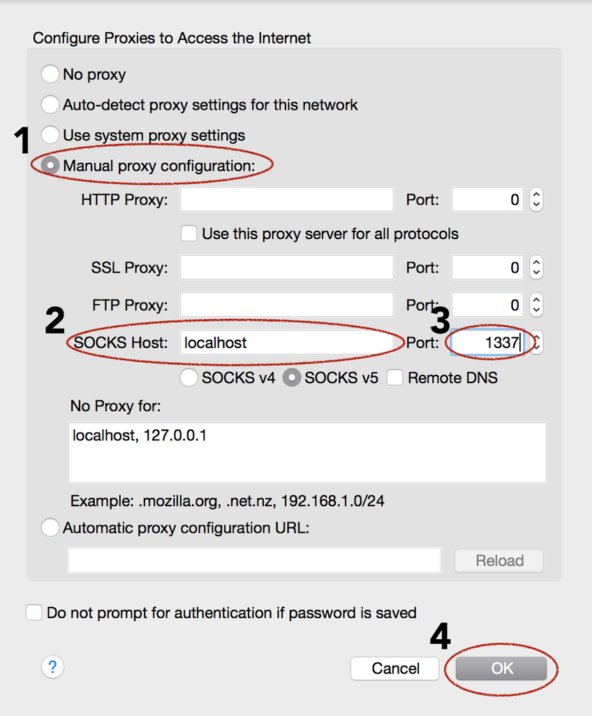

# RStudio on Talapas

Now you have access to port 8787 on the node that you’ve been assigned. Type $ASSIGNED_NODE:8787 in to the browser and you’ve got a full RStudio session running on Talapas. Within RStudio you can use a terminal, use the GUI to upload or remove files, and run whatever you want. You can even write tutorials.

# Cleaning up

Be sure to cancel your interactive session through slurm, or ctrl-c out of the running singualrity image and exit the interactive node ssh session. In macOS, run `ps aux | grep ssh` and `kill` the PID of the ssh tunnel you set up.

# All in one script

```
$ wget https://github.com/jakevc/rstudio_singularity_slurm/blob/master/rstudio_slurm.sh
$ chmod -x rstudio_slurm.sh
$ ./rstudio_slurm.sh -h
Usage: rstudio_slurm.sh [-h] [-n node] [-u remote_user] [-r remote_host] [-p port]
```

To learn more about this script, please visit rstudio_singularity_slurm.

# The script–line by line

```bash
#!/bin/bash
##
## Run Rstudio server through SOCKS5 tunnel on a SLURM allocated node.
## Jake VanCampen, Kohl Kinning, November 2018
##
set -euo pipefail

usage ()
{
     echo "Usage: $(basename $0) [-h] [-n node] [-u remote_user] [-r remote_host] [-p port]" >&2
     exit 1
}

# exit if no arguments supplied
if [ $# -eq 0 ]
then
   usage
   exit 1
fi

# define default local variable
NODE=n013
PORT=8123

# Process command line arguments
while getopts ":h:n::u::r::p:" opt; do
  case ${opt} in
    n ) NODE=$OPTARG ;;
    u ) USER=$OPTARG ;;
    r ) REMOTE=$OPTARG;;
    p ) PORT=$OPTARG;;
    h ) usage;;
    ? ) usage;;
  esac
done
shift $((OPTIND -1))

echo "Writing server command."
# get commands to run Rstudio server on Talapas
echo "#!/bin/bash
/usr/sbin/fuser -k 8787/tcp
module load singularity
singularity pull --name singularity-rstudio.simg shub://nickjer/singularity-rstudio
singularity run --app rserver ~/singularity-rstudio.simg" > rserver.sh

# make sure it's executable
chmod 755 rserver.sh

echo "Copying runscript to HPC."
echo "rsync -av rserver.sh $USER@$REMOTE:~/"
rsync -av rserver.sh $USER@$REMOTE:~/

# remove rserver.sh from your machine
rm rserver.sh

echo "Starting Rstudio server on $NODE."
# Start the Rserver
ssh $USER@$REMOTE -o RemoteCommand="srun -w $NODE rserver.sh" &


echo "Create SOCKS5 proxy tunnel from $NODE, through $REMOTE, to localhost:$PORT."
# forward the port using a proxy command
ssh -D $PORT -N -f -C -q -o ProxyCommand="ssh $USER@$REMOTE exec nc %h %p" $USER@$NODE
```

## Initialize, set up arg input

```bash
set -euo pipefail

usage ()
{
     echo "Usage: $(basename $0) [-h] [-n node] [-u remote_user] [-r remote_host] [-p port]" >&2
     exit 1
}

# exit if no arguments supplied
if [ $# -eq 0 ]
then
   usage
   exit 1
fi

# define default local variable
NODE=n013
PORT=8123

# Process command line arguments
while getopts ":h:n::u::r::p:" opt; do
  case ${opt} in
    n ) NODE=$OPTARG ;;
    u ) USER=$OPTARG ;;
    r ) REMOTE=$OPTARG;;
    p ) PORT=$OPTARG;;
    h ) usage;;
    ? ) usage;;
  esac
done
shift $((OPTIND -1))
```

## Writing server command

Write the server command to be run on a SLURM node and save it in to a script. Make the script executable and copy it to Talapas, your home directory (~/) using rsync. We use rsync instead of scp because we can retain the original permissions of the file. Remove the rserver.sh script file from your local storage.

We use module to load Singularity, an operating system virtualization containerization tool. It’s a lot like Docker. When you load up a Singularity image all of the parts an apllication needs, such as libraries and other dependencies, are packaged with it. Lucky for us, there is an RStudio server [Singularity image](https://github.com/nickjer/singularity-rstudio) shared on Github. View the image topology [here](https://singularity-hub.org/containers/3409/view). Once we pull the image we can get it running. By default RStudio server forwards traffic to port 8787–this is the port we’ll connect to later.

```bash
echo "Writing server command."
# get commands to run Rstudio server on Talapas
echo "#!/bin/bash
/usr/sbin/fuser -k 8787/tcp
module load singularity
singularity pull --name singularity-rstudio.simg shub://nickjer/singularity-rstudio
singularity run --app rserver ~/singularity-rstudio.simg" > rserver.sh

# make sure it's executable
chmod 755 rserver.sh

echo "Copying runscript to HPC."
echo "rsync -av rserver.sh $USER@$REMOTE:~/"
rsync -av rserver.sh $USER@$REMOTE:~/

# remove rserver.sh from your machine
rm rserver.sh
```

## Run the script

Request the node defined when the the script was invoked from SLURM with the -w option and run the singularity/rstudio-server script. If the node is full, the script may hang until resources become available. At this point you may need to jump ship and start from the beginning with a different node. If it executes successfully, RStudio server is running! Everything on the server side of things is complete.

```bash
echo "Starting Rstudio server on $NODE."
# Start the Rserver
ssh $USER@$REMOTE -o RemoteCommand="srun -w $NODE rserver.sh" &
```

But how can we access RStudio running on Talapas?

## Access port 8787

The first step of this traffic redirection step is build an SSH tunnel on your local machine. This is similar to a VPN, but there is no need for special clients and paid software. The SOCKS proxy is essentially an special case of an ssh session, but applications can forward their traffic through the tunnel to the server, and then on the server end, the proxy forwards the traffic out to the general Internet.

This command will create a tunnel from you machine to Talapas, followed by an ssh hop to the node you’ve been assigned.

```bash
echo "Create SOCKS5 proxy tunnel from $NODE, through $REMOTE, to localhost:$PORT."
# forward the port using a proxy command
ssh -D $PORT -N -f -C -q -o ProxyCommand="ssh $USER@$REMOTE exec nc %h %p" $USER@$NODE
```

Now everything is in place. You’ll just need to tell your applications to access this tunnel you’ve set up.

## Forward traffic to SOCKS proxy

Firefox allows a simple interface to route traffic through the proxy. macOS user can also set up a system-wide SOCKS5 proxy System Preferences->Network. Users will enter localhost, but the port number for the proxy (3) will be the port specified when invoking the script.

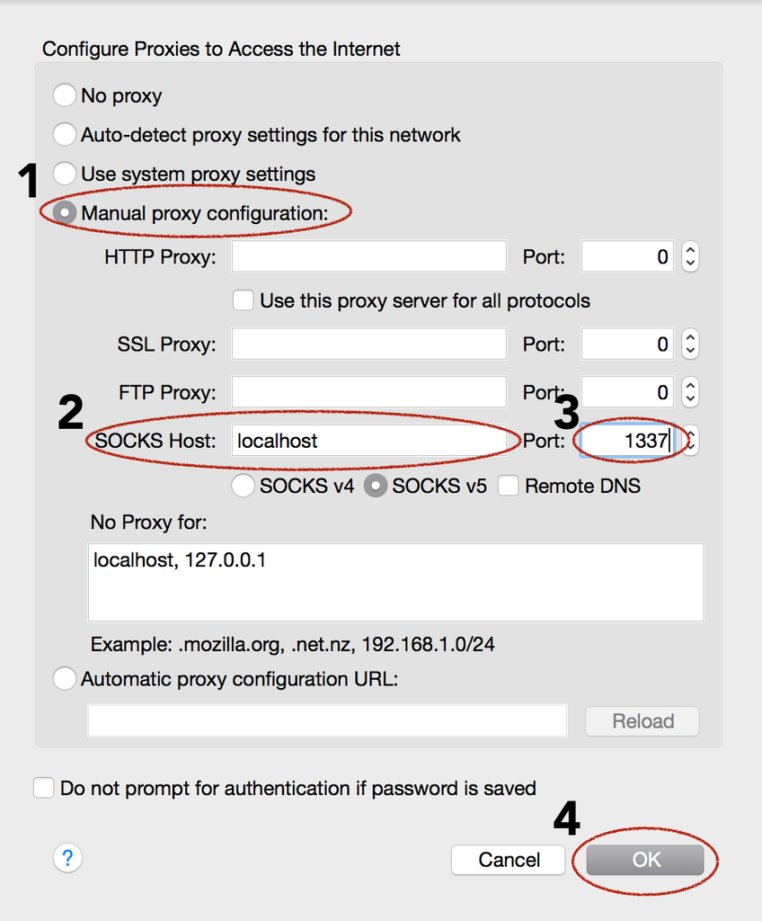